# Progress Report: Indentity Recognition With Masks

# Constructing a faster version of face detection model for potential higher throughput demand

```python
class FastMTCNN(object):
    """Fast MTCNN implementation."""

    def __init__(self, stride, resize=1, *args, **kwargs):
        """Constructor for FastMTCNN class.

        Arguments:
            stride (int): The detection stride. Faces will be detected every `stride` frames
                and remembered for `stride-1` frames.

        Keyword arguments:
            resize (float): Fractional frame scaling. [default: {1}]
            *args: Arguments to pass to the MTCNN constructor. See help(MTCNN).
            **kwargs: Keyword arguments to pass to the MTCNN constructor. See help(MTCNN).
        """
        self.stride = stride
        self.resize = resize
        self.mtcnn = MTCNN(*args, **kwargs)

    def __call__(self, frames):
        """Detect faces in frames using strided MTCNN."""
        if self.resize != 1:
            frames = [
                cv2.resize(f, (int(f.shape[1] * self.resize), int(f.shape[0] * self.resize)))
                    for f in frames
            ]

        boxes, probs = self.mtcnn.detect(frames[::self.stride])

        faces = []
        for i, frame in enumerate(frames):
            box_ind = int(i / self.stride)
            if boxes[box_ind] is None:
                continue
            for box in boxes[box_ind]:
                box = [int(b) for b in box]
                faces.append(frame[box[1]:box[3], box[0]:box[2]])

        return faces
```

# Face detection model implementations

```python
device = torch.device('cuda:0' if torch.cuda.is_available() else 'cpu')
print('Running on device: {}'.format(device))
# currently using, for face detection
mtcnn = MTCNN(keep_all=True, min_face_size=224, device=device)
# A faster model
mtcnn_fast = FastMTCNN(keep_all=True, min_face_size=224, device=device,stride=4)
```

```
Running on device: cuda:0
```

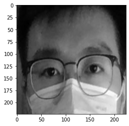

```
(224, 224)
```

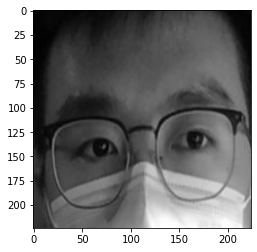

```
(224, 224)
```

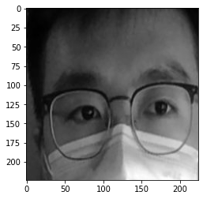

```
(224, 224)
```

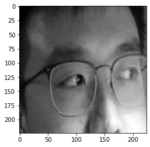

```
(224, 224)
```

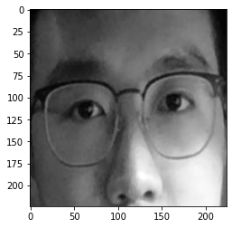

```
(224, 224)
```

```python
from torch.functional import Tensor
video_stream()
label_html = 'Capturing...'
bbox = ''
while True:
    js_reply = video_frame(label_html, bbox)
    if not js_reply:
        break
    # convert JS response to OpenCV Image
    img = js_to_image(js_reply["img"])

    rgb_img = cv2.cvtColor(img, cv2.COLOR_BGR2RGB)
    #frame_fast = torch.from_numpy(rgb_img)
    #frame_fast = torch.stack([frame_fast], dim=0) #Prepared input frame for mtcnn_fast model
    frame = Image.fromarray(rgb_img) #Input frame for mtcnn face detection model



    faces, _ = mtcnn.detect(frame) #return coordinates of faces
    #faces_fast = mtcnn_fast(frame_fast) #higher throughput, return captured faces
    #plt.imshow(faces_fast[0].detach().numpy(), cmap = 'gray')
    #plt.show()

    bbox_array = np.zeros([720,720,4], dtype=np.uint8) #Transparent overlay for drawing bounding box

    if faces is not None:
      for (x,y,w,h) in faces:
        x_w_diff = int(w-x)
        y_h_diff = int(h-y)
        if x_w_diff > 223. and y_h_diff >223.:
          x_w_mid = int(x+(w-x)/2)
          y_h_mid = int(y+(h-y)/2)
          selected_x = x_w_mid - 112
          selected_w = x_w_mid + 112
          selected_y = y_h_mid - 112 - 50
          selected_h = y_h_mid + 112 - 50

          #selected_img = img[int(y):int(y) + x_w_diff,int(x):int(x)+ x_w_diff,:]
          selected_img = img[selected_y:selected_h, selected_x:selected_w, :]
          selected_frame = cv2.cvtColor(selected_img, cv2.COLOR_BGR2GRAY)
          plt.imshow(selected_frame, cmap = 'gray')
          plt.show()
          print(selected_frame.shape)

          input_for_face_recognition = torch.from_numpy(selected_frame)
          input_for_face_recognition = torch.stack([input_for_face_recognition], dim=0) #Prepared input in tensor format


          # Facial recognition process will be placed here






          #
          box_height = (w,int(h-(20)))
          bbox_array = cv2.rectangle(bbox_array,(x,y), box_height, (0,255,0), 2) #Bounding box size and colour
      bbox_array[:,:,3] = (bbox_array.max(axis = 2) > 0 ).astype(int) * 255
      bbox_bytes = bbox_to_bytes(bbox_array) # converting overlay of bbox into bytes
      bbox =bbox_bytes # update bbox for the next frame
```

```python
%%shell
jupyter nbconvert --to html Project_Face_detection.ipynb
```

# Part 2: Model Training

```python
from google.colab import drive
drive.mount('/content/drive')
```

```python
from os import listdir
from os.path import isfile, join
import os
import re
import shutil
import numpy as np
import torch
import torch.nn as nn
import torch.nn.functional as F
import torchvision
from torch.utils.data.sampler import SubsetRandomSampler
from torchvision import datasets, transforms
import torch.optim as optim
import matplotlib.pyplot as plt
from tqdm import tqdm
from PIL import Image
import matplotlib.pyplot as plt

use_cuda = True
```

```python
def split_data(dataset_path, batch_size = 64):
  torch.manual_seed(1)
  np.random.seed(1)

  transform = transforms.Compose([transforms.Resize((224,224)),
                  # transforms.ColorJitter(), # change image color
                  transforms.RandomHorizontalFlip(), # flip images
                  # transforms.RandomAffine(30), # Random affine transformation of the image keeping center invariant.
                  # transforms.CenterCrop(224),
                  transforms.ToTensor()])

  training_dataset = datasets.ImageFolder(root = dataset_path, transform=transform)

  indices = list(range(len(training_dataset)))

  train_indices = []

  val_indices = []

# split data with ratio 8:2
  for i in indices:
    if i % 10 > 7:
      val_indices.append(i)
    else:
      train_indices.append(i)

  np.random.shuffle(train_indices)

  np.random.shuffle(val_indices)

  train_sampler = SubsetRandomSampler(train_indices)
  val_sampler = SubsetRandomSampler(val_indices)

  train_loader, val_loader = torch.utils.data.DataLoader(training_dataset, batch_size=batch_size, sampler=train_sampler), \
                torch.utils.data.DataLoader(training_dataset, batch_size=batch_size, sampler=val_sampler)

  return train_loader, val_loader
```

```python
# set data path
ori_path = '/content/drive/MyDrive/ut/MIE1517_project_dataset/orl/images/'
group_folder_path = '/content/drive/MyDrive/ut/MIE1517_project_dataset/orl/grouped_images/'
files = [f for f in listdir(ori_path) if isfile(join(ori_path, f))]
```

```python
# extract images and labels and store into target folder
for single_file in files:
  group = single_file.split("_")[1].split('.')[0]
  folder_path = group_folder_path + group

  if not os.path.exists(folder_path):
    print("Directory '{}' is created!".format(group))
    os.makedirs(folder_path)

  shutil.copyfile(ori_path + single_file, folder_path + '/' + single_file)
```

```python
group_folder_path = '/content/drive/MyDrive/ut/MIE1517_project_dataset/orl/grouped_images/'

train_loader, val_loader = split_data(group_folder_path, batch_size = 1)
```

```python
print('Training images we have:', len(train_loader))
print('Validation images we have:', len(val_loader))
```

```
Training images we have: 328
Validation images we have: 82
```

```python
# define model to adapt Alex Model
class AlexNetModel(nn.Module):

    def __init__(self):
        super(AlexNetModel, self).__init__()
        self.name = 'AlexNetModel'
        self.conv1 = nn.Conv2d(256, 30, 3)
        self.pool = nn.MaxPool2d(2, 2)
        self.fc1 = nn.Linear(120, 64)
        self.fc2 = nn.Linear(64, 41)

    def forward(self, x):
        x = self.pool(F.relu(self.conv1(x)))
        x = x.view(-1, 120)
        x = F.relu(self.fc1(x))
        x = self.fc2(x)
        return x
```

```python
# function to save checkpoint
def save_checkpoint(model, batch_size, lr, epoch):
  model_path = "{}_{}_{}_{}".format(model.name, batch_size, lr, epoch)
  torch.save(model, model_path)
  print('Checkpoint of {} has been stored successfully!',format(model_path))

def get_accuracy(model, data_loader, grey_images_flag = False):
  correct = 0
  total = 0

  alexnet = torchvision.models.alexnet(pretrained=True)

  for imgs, labels in data_loader:
    #############################################
    #To Enable GPU Usage

    if grey_images_flag:

      grey_images = torchvision.transforms.Grayscale()(imgs)

      imgs = torch.tensor(np.tile(grey_images, [1,3,1,1]))

    imgs = alexnet.features(imgs)

    if use_cuda and torch.cuda.is_available():
      imgs = imgs.cuda()
      labels = labels.cuda()
    #############################################

    output = model(imgs)

    #select index with maximum prediction score
    pred = output.max(1, keepdim=True)[1]
    correct += pred.eq(labels.view_as(pred)).sum().item()
    total += imgs.shape[0]
  return correct / total

def train(model, dataset_path, opt, batch_size = 64, learning_rate=0.01, epochs=30, grey_images_flag = False):

  #############################################
  # input: grey_images_flag: boolean if gray image conversion is needed
  #############################################

  train_loader, val_loader = split_data(dataset_path, batch_size = batch_size)

  criterion = nn.CrossEntropyLoss()

  optimizer = opt(model.parameters(), lr=learning_rate)

  iters, losses, train_acc, val_acc = [], [], [], []

  alexnet = torchvision.models.alexnet(pretrained=True)

  n = 0 # the number of iterations
  for epoch in range(epochs):
    for imgs, labels in tqdm(iter(train_loader)):

      if grey_images_flag:

        grey_images = torchvision.transforms.Grayscale()(imgs)

        imgs = torch.tensor(np.tile(grey_images, [1,3,1,1]))

      imgs = alexnet.features(imgs)

      #############################################
      #To Enable GPU Usage
      if use_cuda and torch.cuda.is_available():
        imgs = imgs.cuda()
        labels = labels.cuda()
      #############################################

      output = model(imgs)
      loss = criterion(output, labels)
      loss.backward()
      optimizer.step()
      optimizer.zero_grad()

    # save the current training information
    iters.append(n)
    losses.append(float(loss)/batch_size)
    train_acc.append(get_accuracy(model, train_loader, grey_images_flag = grey_images_flag))
    val_acc.append(get_accuracy(model, val_loader, grey_images_flag = grey_images_flag))
    n += 1

    if ((epoch+1) % 25 == 0):
      save_checkpoint(model, batch_size, learning_rate, epoch+1)

  # plotting
  plt.title("Training Curve")
  plt.plot(iters, losses, label="Train")
  plt.xlabel("Iterations")
  plt.ylabel("Loss")
  plt.show()

  plt.title("Training Curve")
  plt.plot(iters, train_acc, label="Train")
  plt.plot(iters, val_acc, label="Validation")
  plt.xlabel("Iterations")
  plt.ylabel("Training Accuracy")
  plt.legend(loc='best')
  plt.show()

  print("Final Training Accuracy: {}".format(train_acc[-1]))
  print("Final Validation Accuracy: {}".format(val_acc[-1]))
```

```
CUDA is not available.  Training on CPU ...
```

```
Checkpoint of {} has been stored successfully! AlexNetModel_32_0.001_25
```

```
Checkpoint of {} has been stored successfully! AlexNetModel_32_0.001_50
```

```
Checkpoint of {} has been stored successfully! AlexNetModel_32_0.001_75
```

```
Checkpoint of {} has been stored successfully! AlexNetModel_32_0.001_100
```

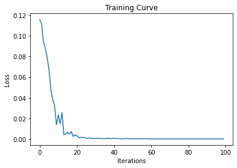

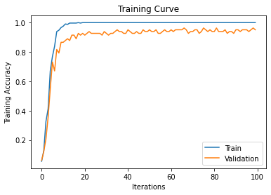

```
Final Training Accuracy: 1.0
Final Validation Accuracy: 0.9512195121951219
```

```python
model = AlexNetModel()

if use_cuda and torch.cuda.is_available():
  model.cuda()
  print('CUDA is available!  Training on GPU ...')
else:
  print('CUDA is not available.  Training on CPU ...')

train(model, group_folder_path, opt = optim.Adam, batch_size = 32, learning_rate=0.001, epochs=100, grey_images_flag = False)
```

# Future plan

As training and testing dataset is clean and standard, adding noise is not neccessary for current phase but could be benefit to real world data. Also, image processing method such as auto-level to scale the distribution of pixels for each channel could also improve our model performance for real world data.

Example:

```python
from skimage import data
from skimage.morphology import disk
from skimage.filters.rank import autolevel
from PIL import Image
```

```python
img = data.camera()
auto = autolevel(img, disk(5))
```

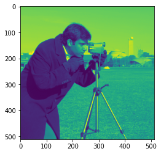

```python
plt.imshow(img)
```

[figure not shown]

```python
plt.imshow(auto)
```

[figure not shown]

```python
plt.imshow(auto, cmap = "gray")
```

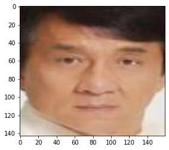

```python
image = Image.open('img_1.jpg')
plt.imshow(image)
```

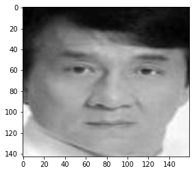

```python
image = torchvision.transforms.Grayscale()(image)
plt.imshow(image, cmap='gray')
```

```python
image = np.asanyarray(image)
image_new = image.copy()
```

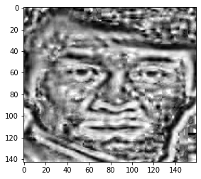

```python
plt.imshow(autolevel(image_new, disk(5)), cmap='gray')
```

```python
def auto_level_img(imgs):
  ret_imgs = []
  imgs = torchvision.transforms.Grayscale()(imgs)
  for i in imgs:
    ret_imgs.append(autolevel(image_new, disk(5)))
```

```python
def train_autolevel(model, dataset_path, opt, batch_size = 64, learning_rate=0.01, epochs=30, grey_images_flag = False):

  #############################################
  # input: grey_images_flag: boolean if gray image conversion is needed
  #############################################

  train_loader, val_loader = split_data(dataset_path, batch_size = batch_size)

  criterion = nn.CrossEntropyLoss()

  optimizer = opt(model.parameters(), lr=learning_rate)

  iters, losses, train_acc, val_acc = [], [], [], []

  alexnet = torchvision.models.alexnet(pretrained=True)

  n = 0 # the number of iterations
  for epoch in range(epochs):
    for imgs, labels in tqdm(iter(train_loader)):

      if grey_images_flag:

        grey_images = torchvision.transforms.Grayscale()(imgs)

        grey_images = auto_level_img(grey_images)

        imgs = torch.tensor(np.tile(grey_images, [1,3,1,1]))

      imgs = alexnet.features(imgs)

      #############################################
      #To Enable GPU Usage
      if use_cuda and torch.cuda.is_available():
        imgs = imgs.cuda()
        labels = labels.cuda()
      #############################################

      output = model(imgs)
      loss = criterion(output, labels)
      loss.backward()
      optimizer.step()
      optimizer.zero_grad()

    # save the current training information
    iters.append(n)
    losses.append(float(loss)/batch_size)
    train_acc.append(get_accuracy(model, train_loader, grey_images_flag = grey_images_flag))
    val_acc.append(get_accuracy(model, val_loader, grey_images_flag = grey_images_flag))
    n += 1

    if ((epoch+1) % 25 == 0):
      save_checkpoint(model, batch_size, learning_rate, epoch+1)

  # plotting
  plt.title("Training Curve")
  plt.plot(iters, losses, label="Train")
  plt.xlabel("Iterations")
  plt.ylabel("Loss")
  plt.show()

  plt.title("Training Curve")
  plt.plot(iters, train_acc, label="Train")
  plt.plot(iters, val_acc, label="Validation")
  plt.xlabel("Iterations")
  plt.ylabel("Training Accuracy")
  plt.legend(loc='best')
  plt.show()

  print("Final Training Accuracy: {}".format(train_acc[-1]))
  print("Final Validation Accuracy: {}".format(val_acc[-1]))
```

```
CUDA is not available.  Training on CPU ...
```

```
Checkpoint of {} has been stored successfully! AlexNetModel_32_0.001_25
```

```
Checkpoint of {} has been stored successfully! AlexNetModel_32_0.001_50
```

```
Checkpoint of {} has been stored successfully! AlexNetModel_32_0.001_75
```

```
Checkpoint of {} has been stored successfully! AlexNetModel_32_0.001_100
```

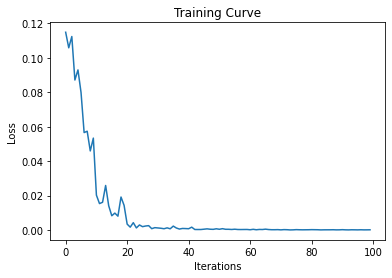

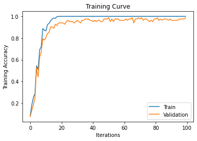

```
Final Training Accuracy: 1.0
Final Validation Accuracy: 0.9878048780487805
```

```python
model_auto_level = AlexNetModel()

if use_cuda and torch.cuda.is_available():
  model_auto_level.cuda()
  print('CUDA is available!  Training on GPU ...')
else:
  print('CUDA is not available.  Training on CPU ...')

train(model_auto_level, group_folder_path, opt = optim.Adam, batch_size = 32, learning_rate=0.001, epochs=100, grey_images_flag = True)
```